# Predicting Resource Suitability with rsMove

### Identify absence samples

In the previous steps we translated the `shortMove` dataset into samples that likely relate to feeding sites. However, to distinguish them from the rest of the landscape, we need to collect background samples that describe “unattractive” environmental conditions. While movement data is a strong asset to understand the environmental preferences of an animal it tells us little about its dislikes. Even if a location was not visited by an animal it does not mean it was unsuitable. Factors such as distance and accessibility can condition animal decision making leading it to neglect potentially suitable resources. Thus, random background sampling - a commonly used technique - can be misleading as it does not account for the abundance of suitable resources. To address this issue we developed `backSample()`. This function introduces a new sampling technique that uses presence samples as informants. These are used to collect samples from the remote sensing data and identify pixels where the environmental conditions are statistically different while preserving fuzzy borders between presences and background samples.

This approach is also sensitive to differences in resource selection. For example, let’s consider our target species. While the White Stork often searches for prey in recently managed crop fields it can sometimes be found over grasslands and even wetlands. As a consequence, our presence samples can reflect a diverse set of environmental conditions. To account for this and to better define the boundaries between suitable and unsuitable environmental conditions, `backSample()` requires indices for each sample that reflect their spatial aggregation. This index is returned by `labelSample()` which aggregates the elements of `SpatialPoints` object based on their spatial neighborhood within a `RasterLayer`. In this exercise, we will aggregate samples within 60m of each other (i.e. 2 pixels).

```r
sample.id <- labelSample(presence.samples, ndvi, agg.radius=60) # aggregate samples in space
absence.samples <- backSample(presence.samples, ndvi, sample.id, sampling.method="pca") # identify absence samples
absence.samples # show samples
```

```
## class       : SpatialPointsDataFrame
## features    : 266
## extent      : 494700, 495150, 5288220, 5288790  (xmin, xmax, ymin, ymax)
## coord. ref. : +proj=utm +zone=32 +datum=WGS84 +units=m +no_defs +ellps=WGS84 +towgs84=0,0,0
## variables   : 3
## names       : X2013.07.16_ndvi, X2013.08.01_ndvi, X2013.08.17_ndvi
## min values  :             2569,             2501,             2556
## max values  :             8528,             9061,             8786
```

### Derive and Validate Predict Model

Similarly to the background sampling approach, the modelling of resource suitability relies on spatially independent samples for training and validation. The function iterates through each of the presence regions given by `sample.id` and uses the corresponding samples for validation while the remaining ones are used for training. During this process, a random set of absence samples is selected. Ideally, the function will try to try to equalize the number of presence samples in the training and validation sets. The final validation is an F1-score estimated from the total number of correct and false positives among all iterations. The function `predictResources()` can be used to perform the training and validation steps.

```r
env.presences <- extract(ndvi, presence.samples) # extract environmental data for presences
env.absences <- extract(ndvi, absence.samples)  # extract environmental data for absences
resourceModel1 <- predictResources(env.presences, env.absences, sample.id, env.data=ndvi) # build model
```

Now let’s have a look at our results. First, let’s make a mask from the output probability map with a threshold of 0.5. Then let’s overlap the presence samples.

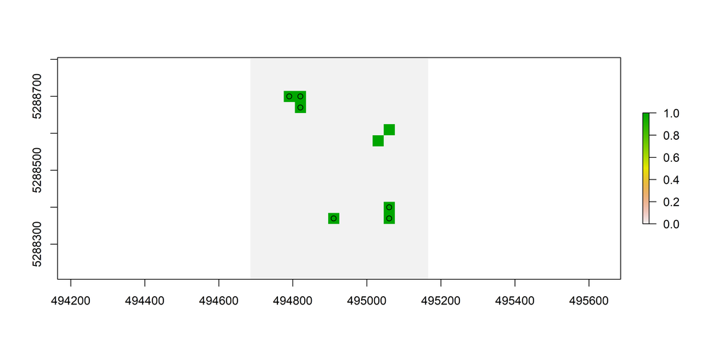

```r
plot(resourceModel1$probabilities >= 0.5) # probability map
points(presence.samples) # presences
```

| presence | absence |
| --- | --- |
| 0.6666667 | 0.9943925 |

The accuracies were comparatively higher for absences suggesting an unbalance betwene both classes. This indicates that the chosen environmental predictors might not be suitable to distinguish the selected resources from their surroundings. But what if we had used random background sampling instead of of the proposed approach?

```r
absence.samples <- backSample(presence.samples, ndvi, sampling.method="random") # identify absence samples (random)
env.absences <- extract(ndvi, absence.samples)  # extract environmental data for absences
resourceModel2 <- predictResources(env.presences, env.absences, sample.id, env.data=ndvi) # build model
```

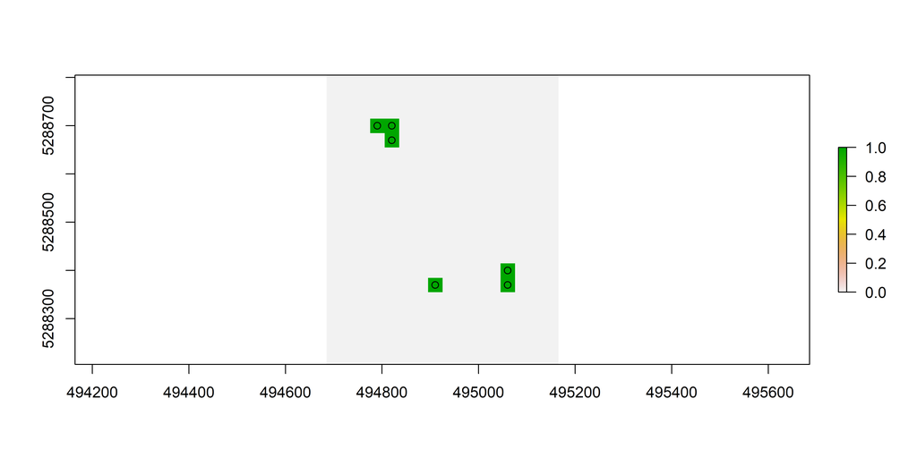

```r
plot(resourceModel2$probabilities >= 0.5) # probability map
points(presence.samples) # presences
```

```r
kable_styling(kable(head(resourceModel2$f1, 1), format="html", align="c", full_width=TRUE), "stripped", bootstrap_options="responsive")
```

| presence | absence |
| --- | --- |
| NaN | 0.9905363 |

As shown by the output, only the samples covered by *presence.samples* received a probability higher than 0.5. Additionally, the F1-score was *NaN* for presences suggesting that the independent presence regions failed to predict each other.

### Plausibility Test

While modelling results might be satisfactory it is ideal to verify if they fit to our expectations, be them data driven or based on empirical observations of the target species. To assist on this, we developed `plausibilityTest()`. This function allows its user to compare presence-absence maps derived with different modelling approaches against existing categorical information such as land cover maps. Given a stack of masks - where 1 is the usable value - the function will iterate through each band and report on the sum of pixels for each class in a categorical layer. To test this tool, we can use the land cover data provided through *rsMove*.

```r
landCover <- raster(system.file('extdata', 'landCover.tif', package="rsMove"))
```

Now let’s apply the function using the probability maps derived with *pca* and *random* sampling considering only probabilities higher than 0.5. We will also specify the class labels.

```r
class.labels <- c("Arable land", "Land without use", "Open spaces", "Wetlands", "Permanent crops", "Extraction/Dump sites", "Industrial areas", "Green urban areas")
probMask <- stack(resourceModel1$probabilities> 0.5, resourceModel2$probabilities> 0.5) # stack of probabilities (pca and random)
ptest <- plausibilityTest(probMask, landCover, class.labels=class.labels)
```

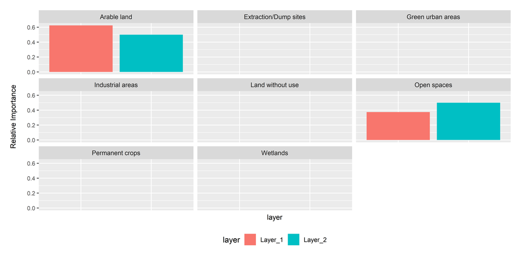

| code | label | Layer_1 | Layer_2 |
| --- | --- | --- | --- |
| 2 | Arable land | 0.625 | 0.5 |
| 3 | Land without use | 0.000 | 0.0 |
| 7 | Open spaces | 0.375 | 0.5 |
| 12 | Wetlands | 0.000 | 0.0 |
| 13 | Permanent crops | 0.000 | 0.0 |
| 15 | Extraction/Dump sites | 0.000 | 0.0 |
| 21 | Industrial areas | 0.000 | 0.0 |
| 23 | Green urban areas | 0.000 | 0.0 |

The output suggests very similar results between both sampling approaches. Most of the pixels with probabilities higher than 0.5 were related to arable land while non-vegetated land cover types as well as *Permanent Crops* were ignored. Considering that the White Stork is reportedly attracted by agriculture, the output of `plausibilityTest()` suggests we built a reasonable predictive model.